# Data Science

# What Is Data Science?

# Three Things

Content knowledge (Science)

Statistics (Math – Weird math, but still math)

Computer Skills (Technology/Computer Engineering)

# Data Science Venn

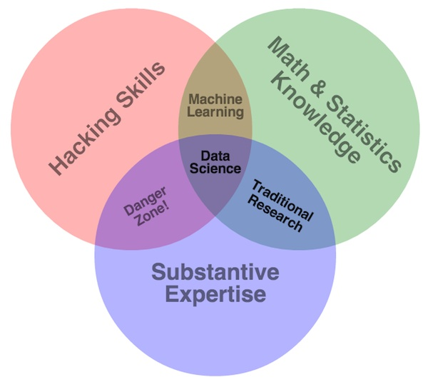

# Statistics

Statistics is a very complex field.

- That does not mean it has to be complicated!

We have two goals in statistics:

> Explain

> Predict

# Explain

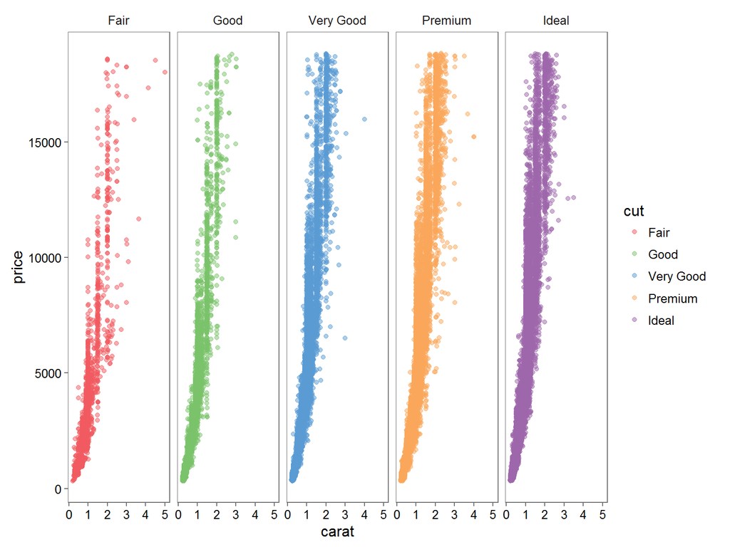

# Predict

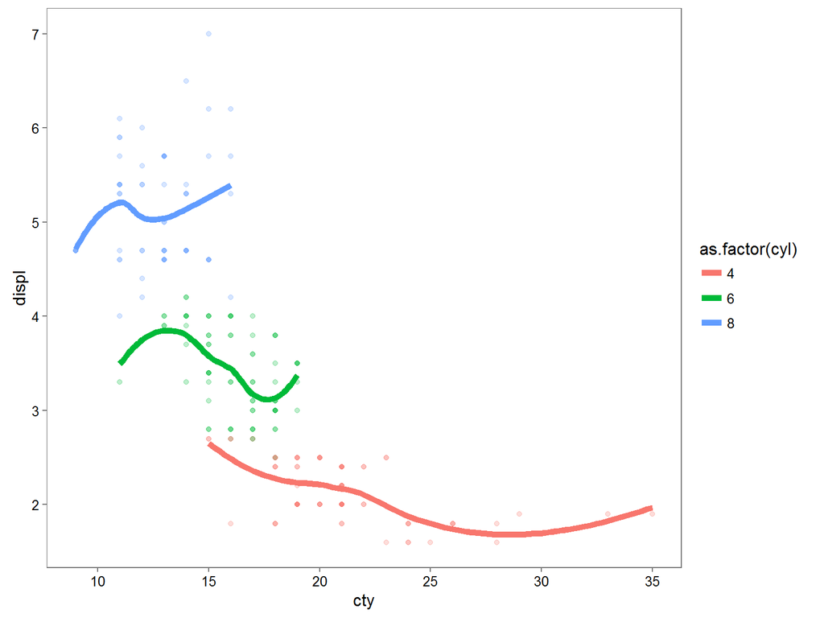

# Computer Science Skills

This is probably the hardest to define.

Computer Science is basically knowing how to really use a computer.

Start simple – try not using a mouse for a day.

# Content Knowledge

This can be anything that interests you!

You just need to know the scientific process!

# The Key

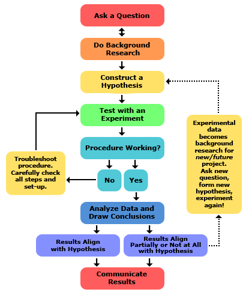

# What Does A Data Scientist Do?

# Solve Problems

Find and arrange data – essentially a huge puzzle.

- Especially from the web.

# Find Relationships

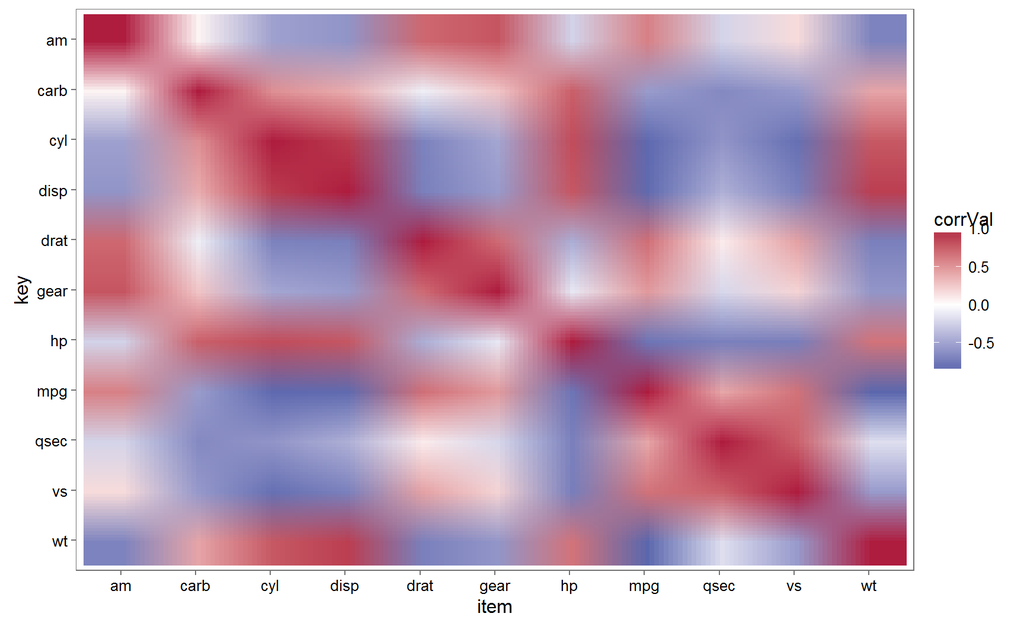

# Have Fun!

# How To Become A Data Scientist!

# Learn How To Write Code

Start small and with purpose!

> Batch scripts

> Regular Expressions

> Cascading Style Sheets

> Javascript

# Getting Domain Knowledge

The beauty of data science lies in its flexibility.

A strong research background, coupled with CS skills, will give you everything you need.

# Learn As Much About Statistics As Possible

Always start at regression.

- It is the foundation for most statistics.

# What Can Data Scientists Do?

Anything!

Work in industry, academia, private consulting, healthcare, military, and just about any other job type.